# ACP Admitidos UNAL Facultad Ciencias

Oscar Julian Layton

7/8/2019

# Admitidos UNAL

Para el primer semestre de 2013 fueron admitidos 445 estudiantes a las carreras de la Facultad de Ciencias. El examen de admision tuvo 5 componentes temáticos: matemático, científico, social, textual e imagen.

### Usando libreria FACTOCLASS

```r
library ( FactoClass )
data( admi ); names( admi )
```

```
##  [1] "carr" "mate" "cien" "soci" "text" "imag" "exam" "gene" "estr" "orig"
## [11] "edad" "niLE" "niMa" "stra" "age"
```

```r
Y <-admi [ ,2:6];head(Y)
```

```
##    mate  cien  soci  text  imag
## 1 12.03 10.84 12.08 10.62 10.68
## 2 11.75 11.16 11.71 10.35 11.60
## 3 10.03 10.51 10.70  9.57  8.80
## 4 11.48 11.48 11.71 10.91 11.60
## 5 11.21 10.84 12.08 11.21 11.26
## 6 11.75 10.84 11.36 10.91 10.96
```

```r
names (Y)
```

```
## [1] "mate" "cien" "soci" "text" "imag"
```

```r
acp <-dudi.pca(Y, scannf =FALSE ,nf =3)
```

Tres valores propios se destacan, pero solo dos son mayores que 1. Seguramente dos son suficientes, pero se debe veri car si el tercer eje permite alguna descripción adicional al primer plano factorial. El primer plano retiene del 57.5% de la inercia y los tres primeros ejes el 74.9 %.

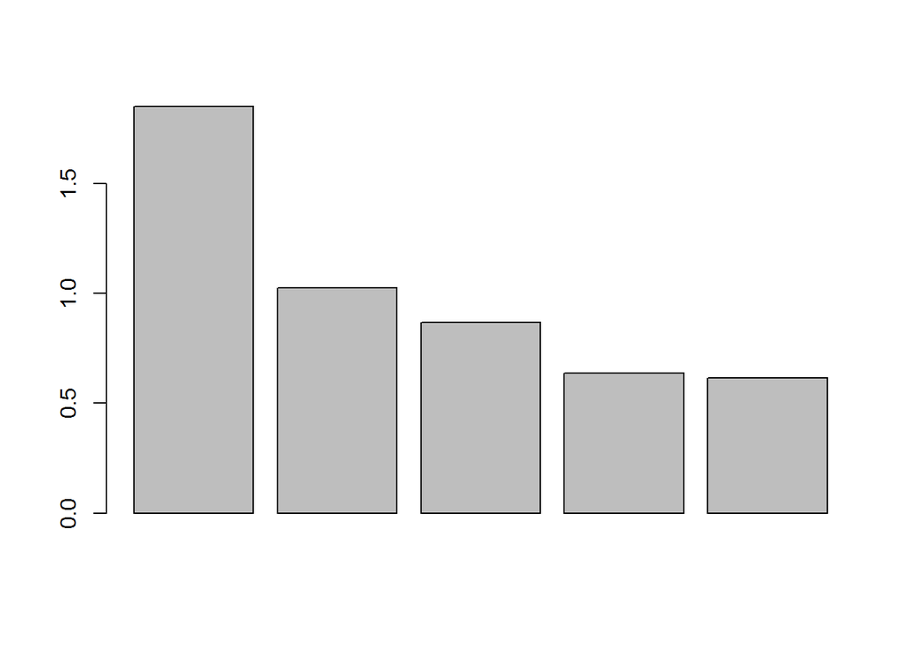

```r
# histograma de valores propios
barplot(acp$eig)
```

```r
# valores propios y proporciones
acp$eig
```

```
## [1] 1.8516980 1.0248954 0.8696715 0.6380381 0.6156969
```

```r
valp <-t(inertia.dudi(acp)$tot.inertia)
xtable (valp , digits = rep (3 ,6))
```

```
## % latex table generated in R 3.6.1 by xtable 1.8-4 package
## % Wed Aug 07 21:25:52 2019
## \begin{table}[ht]
## \centering
## \begin{tabular}{rrrrrr}
##   \hline
##  & Ax1 & Ax2 & Ax3 & Ax4 & Ax5 \\
##   \hline
## inertia & 1.852 & 1.025 & 0.870 & 0.638 & 0.616 \\
##   cum & 1.852 & 2.877 & 3.746 & 4.384 & 5.000 \\
##   cum(\%) & 37.034 & 57.532 & 74.925 & 87.686 & 100.000 \\
##    \hline
## \end{tabular}
## \end{table}
```

### Círculo de correlaciones

```r
#Correlaciones
s.corcircle(acp$co)

# exam como ilustrativa
Gexam <-cor(admi$exam ,acp$li)                  #Exam es la variable relativa al puntaje
rownames( Gexam ) <-" exam "; Gexam
```

```
##             Axis1     Axis2      Axis3
##  exam  -0.9848009 0.1587145 0.02286728
```

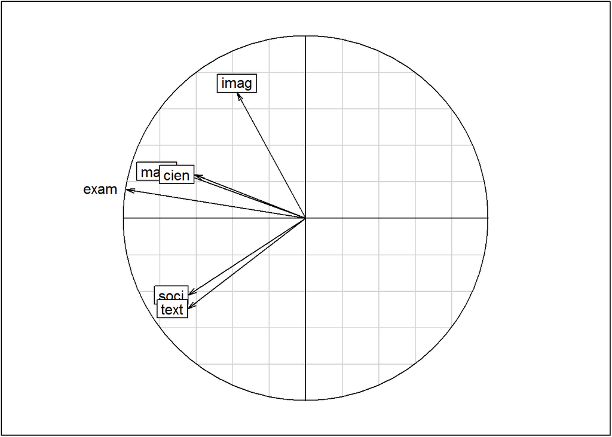

```r
s.arrow(Gexam ,add.plot =TRUE , boxes = FALSE )
```

```r
#dev. print ( device = xfig , file =" acpExaAdmiCirculo .fig ")
# coordenadas
acp$co                                          #Coordenadas de las variablessobre los ejes factoriales
```

```
##           Comp1      Comp2      Comp3
## mate -0.7062207  0.2592443  0.2039603
## cien -0.6120326  0.2416146  0.6016550
## soci -0.6448098 -0.4195867 -0.3511748
## text -0.6478378 -0.4962385 -0.1051525
## imag -0.3780120  0.6906552 -0.5759359
```

```r
#xtable(acp$co , digits = rep (3 ,4))
#xtable(Gexam , digits = rep (3 ,4))
```

se observa un primer eje de tamaño con alta correlación con el puntaje total y con los mejores puntajes con coordenadas negativas (lado izquierdo del eje). El factor tamaño se presenta cuando todas las correlaciones entre las variables activas son positivas y se observan porque tienen coordenadas con el eje del mismo lado. El primer eje se muestra como otra manera de obtener un puntaje global, ya que su correlación con el resultado del examen es de -0.985. Para tener la coordenada en el mismo sentido basta cambiarle de signo a todas las coordenadas sobre el primer eje.

### Primer plano factorial de los admitidos

Los admitidos son anónimos en este ACP, pero las variables cualitativas permiten observar grupos de ellos, según las categorías que asuman. La siguiente figura muestra el primer plano factorial de los individuos con las categorías de las variables cualitativas como ilustrativas.( color verde). La estructura del plano está dada por los resultados del examen, de modo que cualquier ordenamiento de las categorías es indicio de alguna relación con esos resultados.

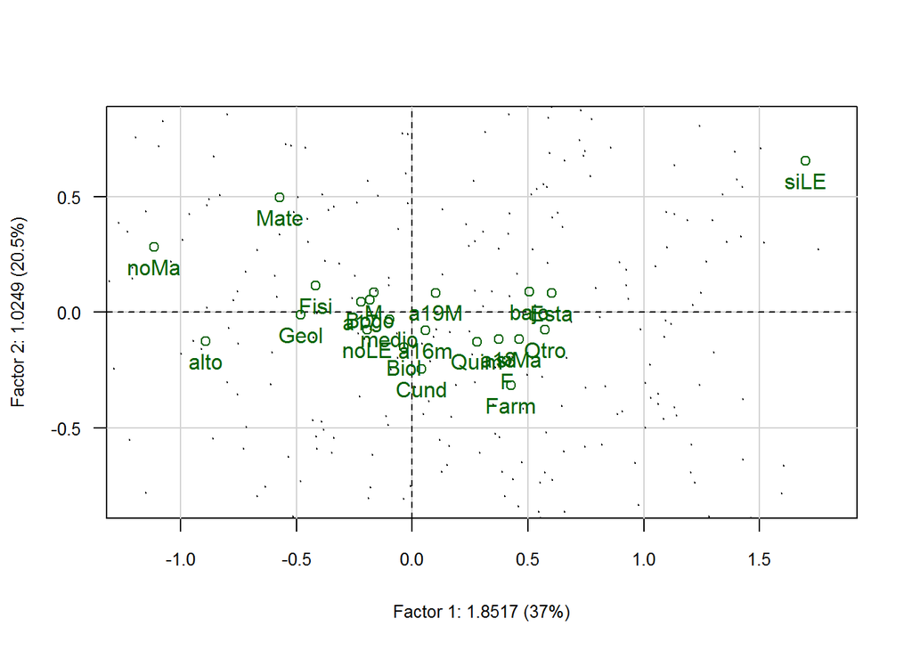

```r
#Primer plano factorial de los admitidos
Ysupcat <-admi[,c (1 ,8:13) ]
sup <- supqual(acp , Ysupcat )
plot(acp,Tcol=FALSE,ucal=100,cex.row =0.2,
       xlim=c( -1 ,1.5),ylim=c( -0.5,0.5))
points(sup$coor ,col=" darkgreen ")            #variables cualitativas como ilustrativas
text( sup$coor , labels = rownames ( sup$ coor ),col=" darkgreen ",pos =1)
```

```r
#dev. print ( device = xfig , file =" acpExaAdmiCatSup .fig ")
```

### Coordenadas, valores test y cosenos cuadrados de las categorías suplementarias

```r
sup                               #Colocando ayudas a la interpretacion
```

```
## $wcat
##       Biol       Esta       Farm       Fisi       Geol       Mate
## 0.14157303 0.14831461 0.16404494 0.18426966 0.10112360 0.11910112
##       Quim          F          M       bajo      medio       alto
## 0.14157303 0.28764045 0.71235955 0.40224719 0.41573034 0.18202247
##       Bogo       Cund       Otro       a16m        a17        a18
## 0.69887640 0.08539326 0.21573034 0.26516854 0.38426966 0.12584270
##       a19M       siLE       noLE       siMa       noMa
## 0.22471910 0.10337079 0.89662921 0.70786517 0.29213483
##
## $dis2
##       Biol       Esta       Farm       Fisi       Geol       Mate
## 0.11702154 0.40292912 0.34639035 0.21358246 0.24384159 0.75121096
##       Quim          F          M       bajo      medio       alto
## 0.10553932 0.22942639 0.03740630 0.26667553 0.02114881 0.87779593
##       Bogo       Cund       Otro       a16m        a17        a18
## 0.03984727 0.08048518 0.38189484 0.05158400 0.07891608 0.16218455
##       a19M       siLE       noLE       siMa       noMa
## 0.05870267 3.63641905 0.04833300 0.30902642 1.81438740
##
## $coor
##             Axis1       Axis2       Axis3
## Biol  -0.03620013 -0.15224858 -0.07958989
## Esta   0.60119855  0.08191392 -0.10856777
## Farm   0.42683316 -0.31535392  0.06828870
## Fisi  -0.41635899  0.11391906  0.10797499
## Geol  -0.48274348 -0.01021110 -0.07121682
## Mate  -0.57276488  0.49638971 -0.01366144
## Quim   0.28038279 -0.12673556  0.03602262
## F      0.41014495 -0.21121215  0.11664668
## M     -0.16561058  0.08528440 -0.04710024
## bajo   0.50623499  0.08763535  0.03465474
## medio -0.09949724 -0.03017223 -0.06780362
## alto  -0.89147006 -0.12475143  0.07827742
## Bogo  -0.18167135  0.05313483 -0.06185569
## Cund   0.03926482 -0.24642737 -0.02516127
## Otro   0.57299714 -0.07459055  0.21034633
## a16m   0.05659854 -0.07911131  0.19515077
## a17   -0.22044709  0.04360735 -0.11847073
## a18    0.37242643 -0.11663009 -0.06823972
```

[output cut: 52 more lines]

```
## a19M  0.17591214 0.1204727714 0.0018857312
## siLE  0.79271184 0.1177376688 0.0413001632
## noLE  0.79271184 0.1177376688 0.0413001632
## siMa  0.68536963 0.0436432532 0.0455130453
## noMa  0.68536963 0.0436432532 0.0455130453
##
## $scr
##           Axis1       Axis2       Axis3
## carr 0.18939106 0.054613432 0.006277124
## gene 0.06792434 0.018013102 0.005494086
## estr 0.25185774 0.006300507 0.003509645
## orig 0.09402752 0.008359044 0.012273165
## edad 0.03929889 0.005691326 0.016102860
## niLE 0.33233356 0.049359902 0.017314527
## niMa 0.51320121 0.032679841 0.034079932
```

```r
wcat=cbind(sup$wcat, d2=sup$dis2, sup$coor, sup$tv, sup$cos2)
colnames(wcat)<-c("Peso","Dist^2", "coordenada1","coordenada2","coordenada3", "Valortesteje1","Valortesteje2","Valortesteje3", "Cosenoeje1","Cosenoeje2","Cosenoeje3");wcat
```

```
##             Peso     Dist^2 coordenada1 coordenada2 coordenada3
## Biol  0.14157303 0.11702154 -0.03620013 -0.15224858 -0.07958989
## Esta  0.14831461 0.40292912  0.60119855  0.08191392 -0.10856777
## Farm  0.16404494 0.34639035  0.42683316 -0.31535392  0.06828870
## Fisi  0.18426966 0.21358246 -0.41635899  0.11391906  0.10797499
## Geol  0.10112360 0.24384159 -0.48274348 -0.01021110 -0.07121682
## Mate  0.11910112 0.75121096 -0.57276488  0.49638971 -0.01366144
## Quim  0.14157303 0.10553932  0.28038279 -0.12673556  0.03602262
## F     0.28764045 0.22942639  0.41014495 -0.21121215  0.11664668
## M     0.71235955 0.03740630 -0.16561058  0.08528440 -0.04710024
## bajo  0.40224719 0.26667553  0.50623499  0.08763535  0.03465474
## medio 0.41573034 0.02114881 -0.09949724 -0.03017223 -0.06780362
## alto  0.18202247 0.87779593 -0.89147006 -0.12475143  0.07827742
## Bogo  0.69887640 0.03984727 -0.18167135  0.05313483 -0.06185569
## Cund  0.08539326 0.08048518  0.03926482 -0.24642737 -0.02516127
## Otro  0.21573034 0.38189484  0.57299714 -0.07459055  0.21034633
## a16m  0.26516854 0.05158400  0.05659854 -0.07911131  0.19515077
## a17   0.38426966 0.07891608 -0.22044709  0.04360735 -0.11847073
## a18   0.12584270 0.16218455  0.37242643 -0.11663009 -0.06823972
## a19M  0.22471910 0.05870267  0.10161944  0.08409562  0.01052129
## siLE  0.10337079 3.63641905  1.69783168  0.65432675  0.38753671
## noLE  0.89662921 0.04833300 -0.19573999 -0.07543617 -0.04467842
## siMa  0.70786517 0.30902642  0.46021443 -0.11613319 -0.11859483
## noMa  0.29213483 1.81438740 -1.11513497  0.28139966  0.28736440
##       Valortesteje1 Valortesteje2 Valortesteje3 Cosenoeje1   Cosenoeje2
## Biol     -0.2276435   -1.28689627    -0.7303152 0.01119836 0.1980800151
## Esta      3.8848718    0.71147853    -1.0236869 0.89703047 0.0166527827
## Farm      2.9278884   -2.90763511     0.6835222 0.52595734 0.2870983523
## Fisi     -3.0642766    1.12694242     1.1595531 0.81165282 0.0607613235
## Geol     -2.5072583   -0.07128539    -0.5397252 0.95570762 0.0004275997
## Mate     -3.2612019    3.79900069    -0.1135024 0.43670769 0.3280073825
## Quim      1.7631788   -1.07124495     0.3305428 0.74488361 0.1521887963
## F         4.0357023   -2.79348255     1.6747947 0.73321504 0.1944439511
## M        -4.0357023    2.79348255    -1.6747947 0.73321504 0.1944439511
## bajo      6.4304929    1.49629332     0.6423359 0.96099506 0.0287988735
## medio    -1.2996207   -0.52973452    -1.2923077 0.46809734 0.0430456119
## alto     -6.5118589   -1.22486735     0.8343382 0.90535721 0.0177295417
## Bogo     -4.2856888    1.68484054    -2.1292238 0.82827442 0.0708532847
## Cund      0.1857824   -1.56723904    -0.1737165 0.01915540 0.7545046928
## Otro      4.6535219   -0.81425117     2.4927097 0.85972809 0.0145687997
```

[output cut: 17 more lines]

```
## M     0.0593063753
## bajo  0.0045034170
## medio 0.2173801468
## alto  0.0069803852
## Bogo  0.0960197756
## Cund  0.0078659158
## Otro  0.1158580171
## a16m  0.7382875034
## a17   0.1778511506
## a18   0.0287121009
## a19M  0.0018857312
## siLE  0.0413001632
## noLE  0.0413001632
## siMa  0.0455130453
## noMa  0.0455130453
```

Las carreras con mejores resultados son Matemáticas, Física y Geología, en oposición a Estadística, Farmacia y Química. Los admitidos a Matemíticas, en promedio, tienen mejores resultados en las pruebas de imagen, matemático y científico. Son pocos los admitidos los que tienen que nivelar lecto-escritura (siLE), y por eso se ubican más lejos, al lado derecho arriba, donde se sitúan los de peores resultados en el examen de admisión. En la nivelación de matemáticas la situación es inversa, y los que no tienen que hacerlo están al lado izquierdo, arriba, de mejores resultados en el examen.

En el tercer eje (ver valores test en la tabla 3.2) se observa que en promedio los que tienen edades de 16 años o menos, por un lado, y los que vienen de otra región, por otro, tienen resultados inferiores en la componente de imagen.

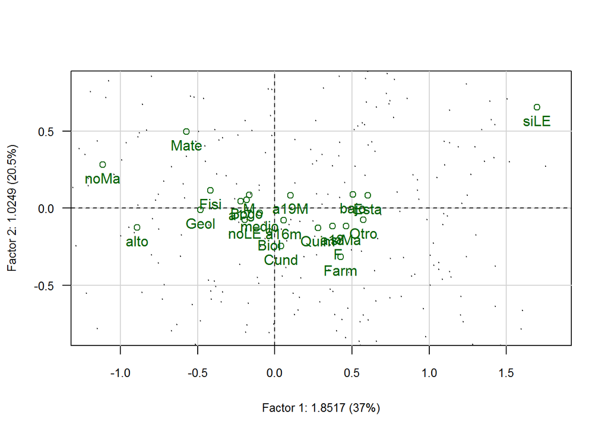

```r
#Primer plano factorial de los admitidos
Ysupcat <-admi[,c (1 ,8:13) ]
sup <- supqual(acp , Ysupcat )
plot(acp,Tcol=FALSE,ucal=100,cex.row =0.2,
       xlim=c( -1 ,1.5),ylim=c( -0.5,0.5))
points(sup$coor ,col=" darkgreen ")            #variables cualitativas como ilustrativas
text( sup$coor , labels = rownames ( sup$ coor ),col=" darkgreen ",pos =1)
```

```r
#dev. print ( device = xfig , file =" acpExaAdmiCatSup .fig ")
```